# Prediction Analysis of personal activity data

## Prediction Analysis of personal activity data

### Summary

The goal of the following analysis is to understand the variables which are important in the data on personal activity with the aim of predicting which class a group of persons belong to given new data on their personal activity.

First, we need to clean that data, which has several NAs as entries. We identify the columns in the training data matrix which have a high percentage of NAs and remove those columns from further analysis. Additionally, only those columns which have arm/forearm/dumbbell/belt are retained as predictor variables. The accelerometers were installed in these locations and therefore these would be the relevant variables to process. In a similar manner to the training data, variables from the testing dataset are removed and the variables (53 of them) which are common to the testing and the training datasets are kept for building a prediction model.

Correlation among the variables is explored next, in order to assess multicollinearity and to remove highly correlated variables. Those variable pairs which have a Pearson correlation coefficient of 0.8 or higher are identified. Potentially one variable of each pair could be removed.

A seed is set using set.seed function, to ensure that the computation is reproducible. A classification and regression tree is built in two ways- 1) doing a preprocessing of the data by centering and scaling the data and 2) without doing the centering and scaling. For the models generated, the importance of the variables is assessed. This identified 14 variables as being important in the prediction.

The result indicates that the prediction accuracy is better in the bigger (53 variable) model than the 14 variable model, but not by much. The choice of variable selection would be a tradeoff between slightly improved accuracy and processing time. Further refinement of the predictor model might including combining various predictors to reduce the out of sample error while minimizing overfitting.

### Read in input data

```r
tr <- read.csv("pml-training.csv")
te <- read.csv("pml-testing.csv")
```

### Explore and preprocess the data

```r
# str(tr); dim(tr) colnames(tr)
table(tr$classe)
```

```
##
##    A    B    C    D    E
## 5580 3797 3422 3216 3607
```

### Identifying NA's

```r
### On the training set
cols.w.nas <- apply(tr, 2, function(x) sum(is.na(x)))
### Remove columns which have high percentage of NAs
cols.to.remove <- names(cols.w.nas[cols.w.nas > 0])
tr2 <- tr[, !colnames(tr) %in% cols.to.remove]
### keep variables pertaining to belt/forearm/arm/dumbbell
ind1 <- grepl("_arm|_forearm|_dumbbell|_belt", colnames(tr2))
tr3 <- cbind(tr2[, ind1], classe = tr2$classe)
# ind2 <- !grepl('yaw',colnames(tr3)) tr4 <- tr3[,ind2] x <- head(tr4,n=100)
cn.tr <- colnames(tr3)
```

```r
### On the testing set
cols.w.nas <- apply(te, 2, function(x) sum(is.na(x)))
cols.to.remove <- names(cols.w.nas[cols.w.nas > 0])
te2 <- te[, !colnames(te) %in% cols.to.remove]
ind1 <- grepl("_arm|_forearm|_dumbbell|_belt", colnames(te2))
te3 <- cbind(te2[, ind1], problem_id = te2$problem_id)
cn.te <- colnames(te3)

common <- intersect(cn.tr, cn.te)
```

### Variable selection

The variables which are common to the training and testing datasets are kept for further processing.

```r
tr4 <- cbind(tr3[, colnames(tr3) %in% common], classe = tr3$classe)
te4 <- cbind(te3[, colnames(te3) %in% common], problem_id = te3$problem_id)
```

### Explore correlation among variables

Several variables can be correlated. This would affect the model building. Such variables are identified below using the 'cor' function using Pearson correlation. Those variable pairs which have a correlation of > 0.8 need to be looked at more closely and appropriately removed.

```r
x <- cor(subset(tr4, select = -classe))
diag(x) <- 0
### the correlated variables
head(which(abs(x) > 0.8, arr.ind = T))
```

```
##                  row col
## yaw_belt           3   1
## total_accel_belt   4   1
## accel_belt_y       9   1
## accel_belt_z      10   1
## accel_belt_x       8   2
## magnet_belt_x     11   2
```

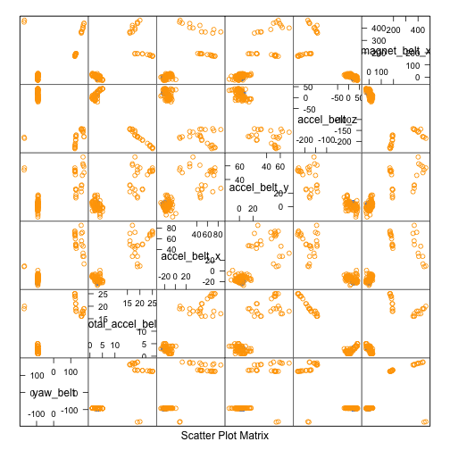

```r
### Look at a feature plot of response with a few predictors
six.cols <- rownames(head(which(abs(x) > 0.8, arr.ind = T)))
tmp1 <- head(data.frame(tr4[, colnames(tr4) %in% six.cols], classe = tr4$classe),
    n = 100)
tmp2 <- tail(data.frame(tr4[, colnames(tr4) %in% six.cols], classe = tr4$classe),
    n = 100)
tmp <- rbind(tmp1, tmp2)
require(caret)
featurePlot(y = tmp$classe, x = subset(tmp, select = -classe), plot = "pairs")
```

### Fit different models on the data

```r
### center and scale, log transformation, Box-Cox??
require(caret)
set.seed(12365)

### Generate a classification and regression tree
mod.rpart.scaled <- train(classe ~ ., data = tr4, preProcess = c("center", "scale"),
    method = "rpart")
mod.rpart <- train(classe ~ ., data = tr4, method = "rpart")
predict(mod.rpart.scaled, te4)
```

```
##  [1] C A C A A C C A A A C C C A C A A A A C
## Levels: A B C D E
```

```r
### boosting, random forest on 53 variables
mod.rf <- train(classe ~ ., data = tr4, method = "rf", trControl = trainControl(method = "cv"),
    number = 3)
mod.gbm <- train(classe ~ ., data = tr4, method = "gbm", verbose = F)  ### takes v long
```

```r
# mod.rf.oob <- train(classe~.,
# data=tr4,method='rf',trControl=trainControl(method='oob'),number=3)

### assess variable importance from the rpart models ### and consider only
### those variables for the RF and boosting models
tmp <- varImp(mod.rpart)
imp.var <- rownames(tmp$importance)[tmp$importance > 0]
tr5 <- cbind(tr4[, colnames(tr4) %in% imp.var], classe = tr4$classe)
te5 <- cbind(te4[, colnames(te4) %in% imp.var], problem_id = te4$problem_id)
# tr6 <- head(tr5,n=1000)
# featurePlot(y=tr6$classe,x=subset(tr6,select=-classe),plot='pairs')

### boosting, random forests on 14 variables (identified as important from a
### classification and regression tree model)
mod.rf.small <- train(classe ~ ., data = tr5, method = "rf", trControl = trainControl(method = "cv"),
    number = 3)
```

### Predictions and Error analysis

```r
pred.gbm <- predict(mod.gbm, te4)
pred.gbm
```

```
##  [1] B A B A A E D B A A B C B A E E A B B B
## Levels: A B C D E
```

```r
pred.rf <- predict(mod.rf, te4)
pred.rf
```

```
##  [1] B A B A A E D B A A B C B A E E A B B B
## Levels: A B C D E
```

```r
pred.rf.oob <- predict(mod.rf.oob, te4)
```

[output not shown]

```r
pred.rf.small <- predict(mod.rf.small, te5)
pred.rf.small
```

```
##  [1] B A B A A E D B A A B C B A E E A B B B
## Levels: A B C D E
```

```r
### Look at confusion matrix for prediction done with 53 variables
confusionMatrix(mod.rf)
```

```
## Cross-Validated (10 fold) Confusion Matrix
##
## (entries are percentages of table totals)
##
##           Reference
## Prediction    A    B    C    D    E
##          A 28.4  0.1  0.0  0.0  0.0
##          B  0.0 19.3  0.1  0.0  0.0
##          C  0.0  0.0 17.4  0.2  0.0
##          D  0.0  0.0  0.0 16.2  0.0
##          E  0.0  0.0  0.0  0.0 18.3
```

```r
### Look at confusion matrix for prediction done with only 14 variables
confusionMatrix(mod.rf.small)
```

```
## Cross-Validated (10 fold) Confusion Matrix
##
## (entries are percentages of table totals)
##
##           Reference
## Prediction    A    B    C    D    E
##          A 28.4  0.1  0.0  0.0  0.0
##          B  0.0 19.1  0.1  0.0  0.0
##          C  0.0  0.2 17.2  0.2  0.0
##          D  0.0  0.0  0.1 16.1  0.1
##          E  0.0  0.0  0.0  0.0 18.3
```

```r
### store the predictions in object 'answers' for the course project
### submission
answers <- pred.rf
```